# Accidents - Regression methods

candice

2022-12-02

## Introduction

This report describes an analysis of the database “Accidents”, in which the data was simulated based on a real dataset of events in French motorway tunnels. Here, we focus on modelling the accidents.

## Exploratory on numerical variables

First, let’s look at the data and try to fit a model to our data distribution.

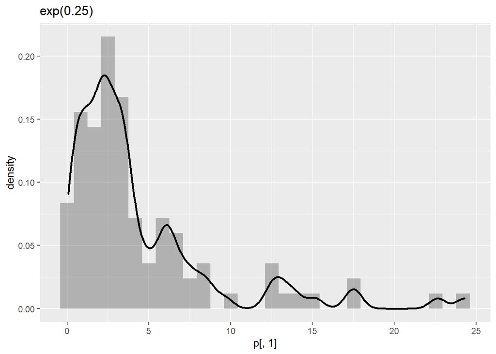

To fit a model, let’s look at the correlations between the different variables and their distributions. This will enable us to understand better how they are possibly linked.

[output not shown]

[output cut: 184 more lines]

[output not shown]

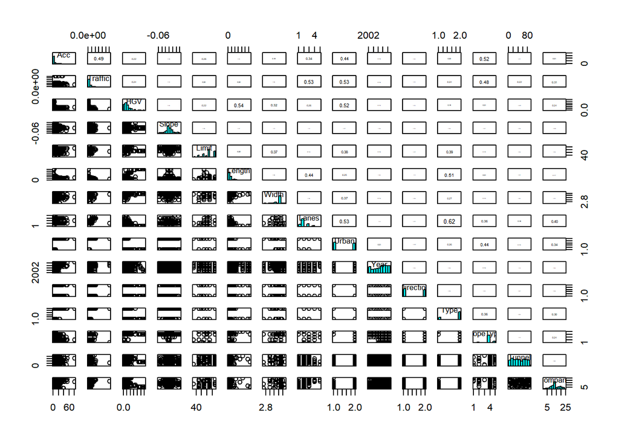

[output not shown]

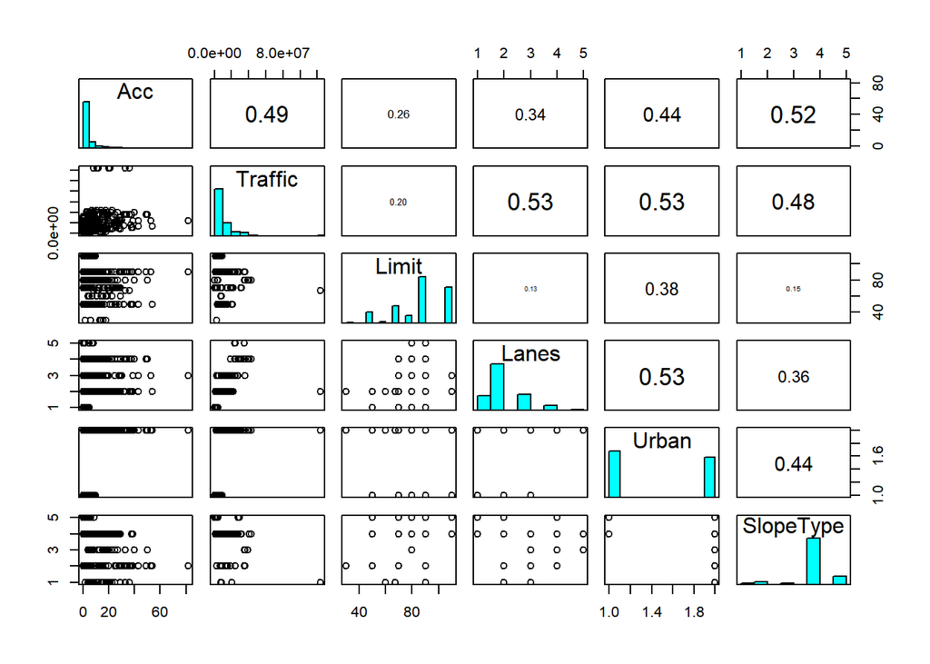

```
##
## Call:
## lm(formula = Acc ~ log(Traffic), data = Accidents)
##
## Residuals:
##    Min     1Q Median     3Q    Max
## -9.720 -3.402 -1.351  1.173 73.149
##
## Coefficients:
##              Estimate Std. Error t value Pr(>|t|)
## (Intercept)  -42.8780     2.5839  -16.59   <2e-16 ***
## log(Traffic)   3.0430     0.1666   18.26   <2e-16 ***
## ---
## Signif. codes:  0 '***' 0.001 '**' 0.01 '*' 0.05 '.' 0.1 ' ' 1
##
## Residual standard error: 6.678 on 1158 degrees of freedom
## Multiple R-squared:  0.2236, Adjusted R-squared:  0.223
## F-statistic: 333.5 on 1 and 1158 DF,  p-value: < 2.2e-16
```

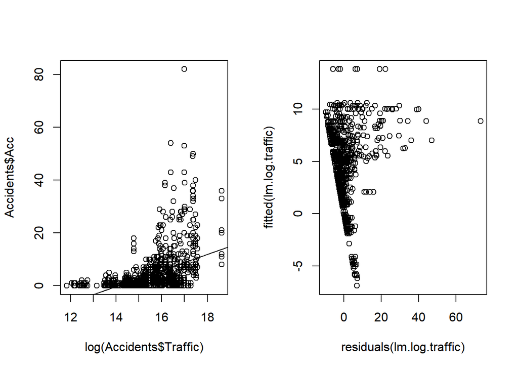

The R squared shows that Traffic is not sufficient to explain the number of accidents, but the p-value indicates that Traffic is significative. The residuals are not homoscedastic, nor normally distributed.

## Exploratory on categorical variables

Let’s look at lanes. With a rapid plot(not visible here), it seems like having two lanes is the case that creates most accidents. Below, I fit a linear regression.

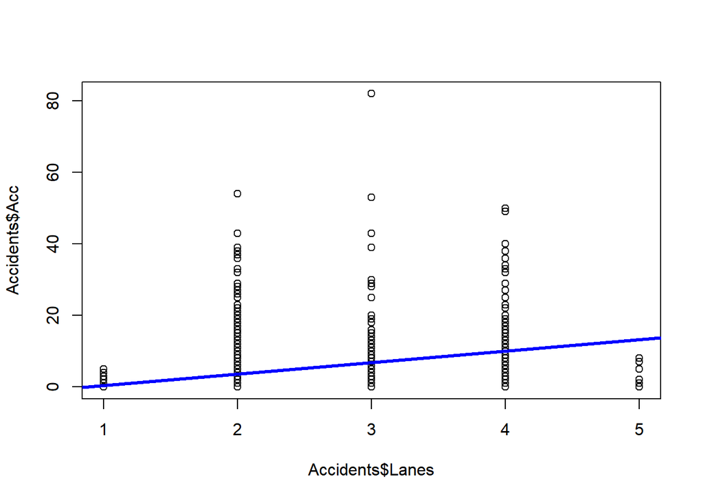

Let’s look at year. There is a net increase of accidents in 2007 compared to before. It still increases in 2008 and then stabilizes.

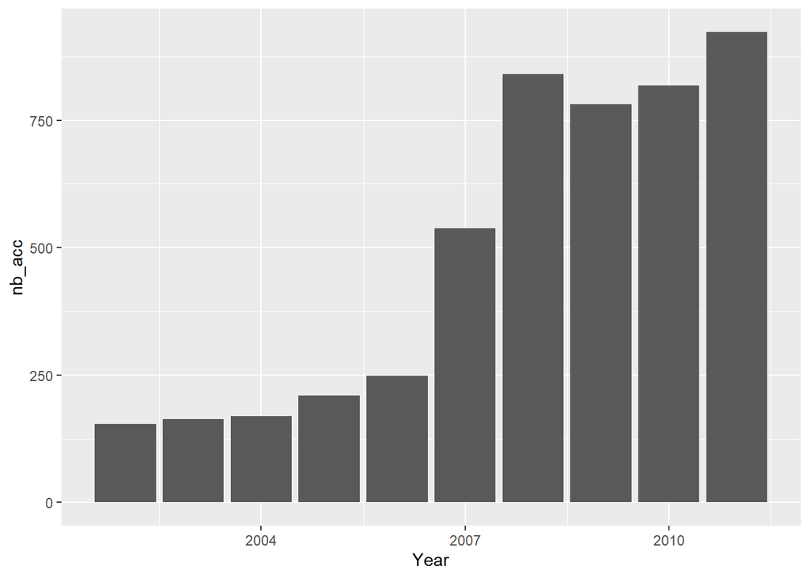

Let’s look at the Urban variable. We can see that most accidents occure in an urban environment.

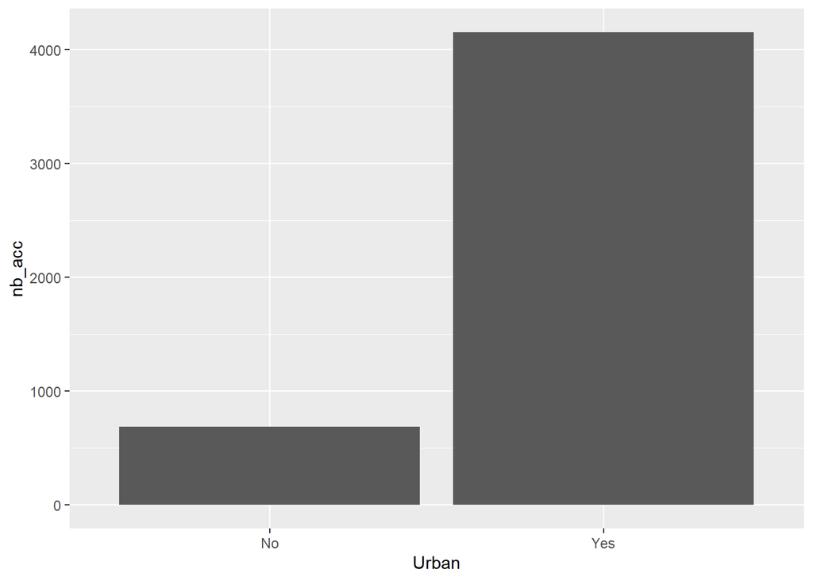

Let’s look at the slope types. There is missing data which will probably need some further analysis.

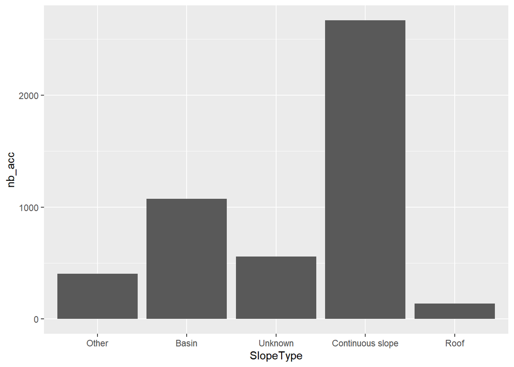

Finally, by looking at the companies and tunnels, one can see an enormous heterogeneity.

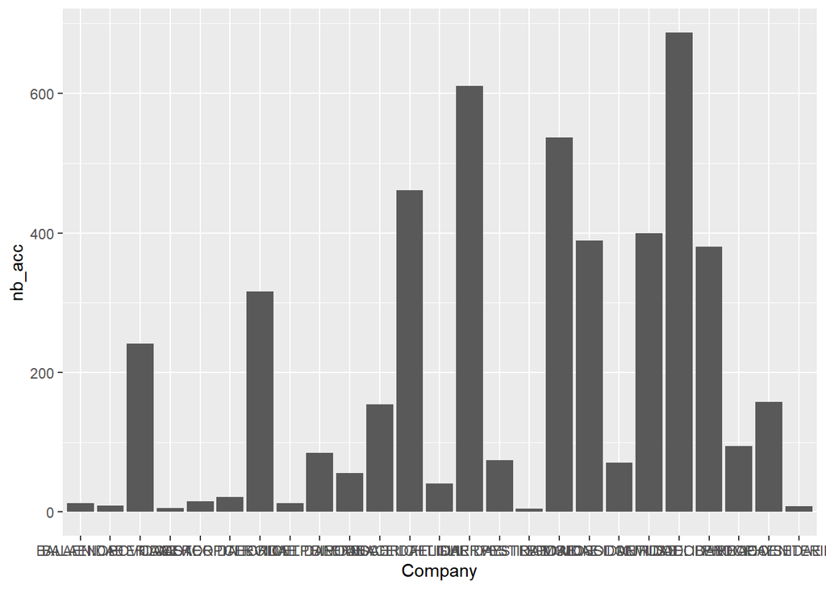

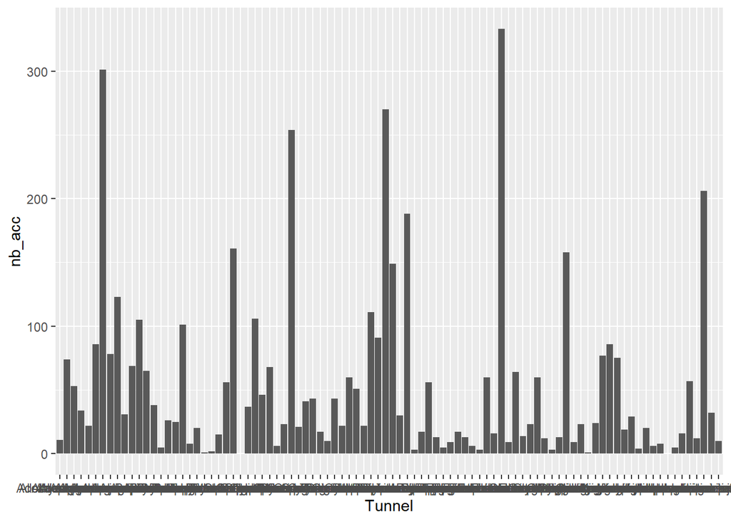

Conclusions of our exploratory analysis :  
*It would probably make sense to consider tunnel and companies as random

*It would maybe be needed to consider two different models depending on the years we are considering

*Numerical variables that look the most helpful to build the model are Traffic, Lanes, HGV and Limit

## Model

*Variable selection for linear model* The first naive way to do it is to do a backward elimination on all the variables. But it gives a model based on companies and tunnel mainly, which is not a true model. Indeed, those effects are random. So, we do the backward elimination without those variables.

```
## Start:  AIC=3999.84
## Acc ~ Direction + Limit + Width + Urban + HGV + log(Traffic) +
##     log(Length) + Type + SlopeType
##
##                Df Sum of Sq   RSS    AIC
## - HGV           1       2.3 35666 3997.9
## - Urban         1       4.9 35669 3998.0
## <none>                      35664 3999.8
## - Direction     1      64.4 35728 3999.9
## - Limit         1     406.9 36071 4011.0
## - Width         1     423.2 36087 4011.5
## - Type          1     561.0 36225 4015.9
## - log(Length)   1    2056.0 37720 4062.9
## - log(Traffic)  1    2097.0 37761 4064.1
## - SlopeType     4    8754.8 44419 4246.5
##
## Step:  AIC=3997.91
## Acc ~ Direction + Limit + Width + Urban + log(Traffic) + log(Length) +
##     Type + SlopeType
##
##                Df Sum of Sq   RSS    AIC
## - Urban         1       3.6 35670 3996.0
## <none>                      35666 3997.9
## - Direction     1      64.2 35730 3998.0
## - Limit         1     408.6 36075 4009.1
## - Width         1     463.2 36129 4010.9
## - Type          1     571.9 36238 4014.4
## - log(Traffic)  1    2107.8 37774 4062.5
## - log(Length)   1    2257.4 37924 4067.1
## - SlopeType     4    8753.3 44420 4244.5
##
## Step:  AIC=3996.03
## Acc ~ Direction + Limit + Width + log(Traffic) + log(Length) +
##     Type + SlopeType
##
##                Df Sum of Sq   RSS    AIC
## <none>                      35670 3996.0
## - Direction     1      65.4 35735 3996.2
## - Limit         1     449.4 36119 4008.6
## - Width         1     467.4 36137 4009.1
## - Type          1     568.8 36239 4012.4
## - log(Length)   1    2253.8 37924 4065.1
## - log(Traffic)  1    3265.3 38935 4095.6
## - SlopeType     4    8753.3 44423 4242.6
```

```
## [1] 7289.965
```

```
## [1] 7350.639
```

```
##
## Call:
## lm(formula = Acc ~ Direction + Limit + Width + log(Traffic) +
##     log(Length) + Type + SlopeType, data = Accidents)
##
## Residuals:
##     Min      1Q  Median      3Q     Max
## -17.770  -2.453  -0.399   1.681  61.073
##
## Coefficients:
##                            Estimate Std. Error t value Pr(>|t|)
## (Intercept)               -19.03500    5.73171  -3.321 0.000925 ***
## DirectionDirection 2       -0.48101    0.33134  -1.452 0.146854
## Limit                      -0.04186    0.01100  -3.805 0.000149 ***
## Width                      -4.28284    1.10377  -3.880 0.000110 ***
## log(Traffic)                1.97716    0.19278  10.256  < 2e-16 ***
## log(Length)                 2.00747    0.23560   8.521  < 2e-16 ***
## TypeUnidirectional          2.64820    0.61868   4.280 2.02e-05 ***
## SlopeTypeBasin              6.28744    1.29930   4.839 1.48e-06 ***
## SlopeTypeUnknown            3.80293    1.45752   2.609 0.009194 **
## SlopeTypeContinuous slope  -5.59021    1.14371  -4.888 1.16e-06 ***
## SlopeTypeRoof              -6.59342    1.25576  -5.251 1.81e-07 ***
## ---
## Signif. codes:  0 '***' 0.001 '**' 0.01 '*' 0.05 '.' 0.1 ' ' 1
##
## Residual standard error: 5.572 on 1149 degrees of freedom
## Multiple R-squared:  0.4637, Adjusted R-squared:  0.459
## F-statistic: 99.35 on 10 and 1149 DF,  p-value: < 2.2e-16
```

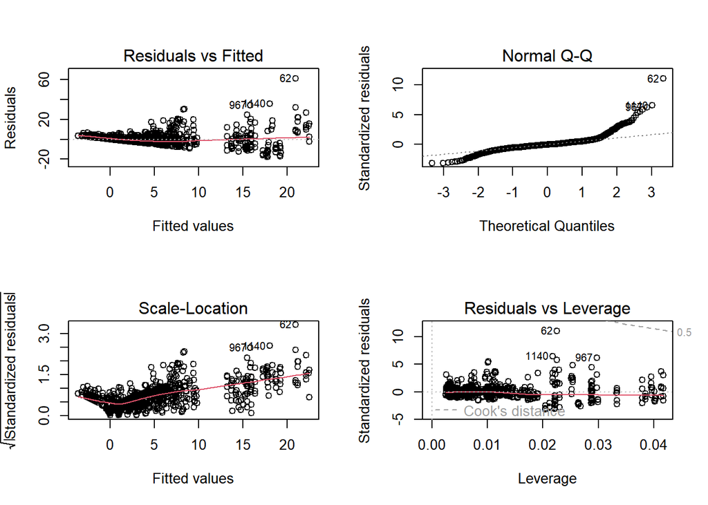

The adjusted R squared is not that bad, but some coefficients are not completely significant. Traffic and log(Length) are extremely significant, as well as Type, Width and Limit. The SlopeType needs further investigation.  
Overall, the linear model is not completely satisfying. In the next section, I try to fit some exponential models.

```
##
##        Family:  Gamma
## Link function:  log
##
## Initial model:
## ~ 1
##
##
## Step 0 :
##                 df    AIC    BIC adj.R-squared P(Chisq>)(*)
## + Urban          1 5453.6 5468.8        0.4109    < 2.2e-16
## + log(Traffic)   1 5454.4 5469.5        0.4106    < 2.2e-16
## + SlopeType      4 5594.4 5624.7        0.3445    < 2.2e-16
## + Lanes          1 5849.9 5865.1        0.2024    < 2.2e-16
## + Limit          1 5963.6 5978.8        0.1315    < 2.2e-16
## + HGV            1 5991.9 6007.0        0.1130    < 2.2e-16
## + Type           1 6006.7 6021.9        0.1032    < 2.2e-16
## + Width          1 6083.0 6098.2        0.0511    1.101e-08
## + Slope          1 6151.1 6166.3        0.0024      0.09139
## + Direction      1 6151.2 6166.4        0.0023      0.15437
## <none>             6153.6 6163.7        0.0000
## + log(Length)    1 6155.3 6170.5       -0.0007      0.68470
##
## Step 1 : + Urban
##
##                 df    AIC    BIC adj.R-squared P(Chisq>)(*)
## + SlopeType      4 5222.6 5257.9        0.5097    < 2.2e-16
## + log(Traffic)   1 5312.1 5332.4        0.4728    < 2.2e-16
## + Lanes          1 5405.7 5426.0        0.4328    1.172e-09
## + Type           1 5409.6 5429.8        0.4311    1.040e-09
## + log(Length)    1 5429.8 5450.0        0.4221    4.021e-06
## <none>             5453.6 5468.8        0.4109
## + Slope          1 5454.0 5474.2        0.4111       0.2514
## + Limit          1 5454.3 5474.5        0.4110       0.3052
## + Width          1 5454.3 5474.5        0.4110       0.3021
## + Direction      1 5454.4 5474.6        0.4110       0.3463
## + HGV            1 5455.3 5475.6        0.4105       0.6610
##
## Step 2 : + SlopeType
##
```

[output cut: 107 more lines]

```
## + Direction      1 4936.4 5012.2        0.6119    0.4000875
## + Lanes          1 4936.8 5012.6        0.6118    0.5521352
## - Urban          1 4938.2 5004.0        0.6107    0.0288976
## - Width          1 4941.2 5006.9        0.6098    0.0106119
## - HGV            1 4949.7 5015.4        0.6071    0.0001263
## - Limit          1 4968.8 5034.5        0.6011    3.178e-08
## - Type           1 4984.0 5049.8        0.5962    4.601e-11
## - log(Traffic)   1 5057.3 5123.1        0.5718    < 2.2e-16
## - SlopeType      4 5090.3 5140.8        0.5595    < 2.2e-16
## - log(Length)    1 5091.5 5157.2        0.5600    < 2.2e-16
##
## Final model:
## ~ Urban + SlopeType + log(Traffic) + log(Length) + HGV + Type + Limit + Width + Slope
##
## (*) p-values of the Wald test
```

```
##
##        Family:  poisson
## Link function:  log
##
## Initial model:
## ~ 1
##
##
## Step 0 :
##                 df     AIC     BIC adj.R-squared P(Chisq>)(*)
## + log(Traffic)   1  7917.5  7927.6        0.4108    < 2.2e-16
## + SlopeType      4  8030.0  8055.3        0.3952    < 2.2e-16
## + Urban          1  8470.4  8480.5        0.3378    < 2.2e-16
## + Lanes          1  9684.0  9694.1        0.1774    < 2.2e-16
## + Limit          1 10208.1 10218.2        0.1081    < 2.2e-16
## + HGV            1 10228.2 10238.3        0.1055    < 2.2e-16
## + Type           1 10435.4 10445.5        0.0781    < 2.2e-16
## + Width          1 10655.5 10665.7        0.0490    < 2.2e-16
## + Direction      1 11010.6 11020.8        0.0021    2.443e-06
## + Slope          1 11016.4 11026.5        0.0013    4.661e-05
## <none>             11031.0 11036.0        0.0000
## + log(Length)    1 11032.0 11042.1       -0.0007       0.3303
##
## Step 1 : + log(Traffic)
##
##                 df    AIC    BIC adj.R-squared P(Chisq>)(*)
## + SlopeType      4 6923.1 6953.4        0.5417    < 2.2e-16
## + log(Length)    1 7474.3 7489.5        0.4692    < 2.2e-16
## + Limit          1 7556.0 7571.2        0.4584    < 2.2e-16
## + Urban          1 7733.6 7748.8        0.4349    < 2.2e-16
## + Width          1 7764.0 7779.2        0.4309    < 2.2e-16
## + HGV            1 7848.3 7863.5        0.4197    < 2.2e-16
## + Direction      1 7882.3 7897.4        0.4152    1.166e-09
## + Type           1 7907.3 7922.4        0.4119    0.0005765
## + Slope          1 7908.1 7923.3        0.4118    0.0007479
## + Lanes          1 7916.2 7931.4        0.4107    0.0702968
## <none>             7917.5 7927.6        0.4108
##
## Step 2 : + SlopeType
##
```

[output cut: 107 more lines]

```
## + Lanes          1 6166.3 6237.1        0.6417     0.732473
## + Urban          1 6166.4 6237.2        0.6417     0.976720
## - Slope          1 6169.9 6230.6        0.6413     0.005998
## - Direction      1 6178.9 6239.6        0.6401    4.873e-05
## - Width          1 6214.2 6274.9        0.6354    4.945e-13
## - Type           1 6307.4 6368.1        0.6230    < 2.2e-16
## - Limit          1 6386.8 6447.4        0.6124    < 2.2e-16
## - log(Length)    1 6641.1 6701.8        0.5785    < 2.2e-16
## - SlopeType      4 6740.9 6786.4        0.5655    < 2.2e-16
## - log(Traffic)   1 6988.7 7049.4        0.5322    < 2.2e-16
##
## Final model:
## ~ log(Traffic) + SlopeType + log(Length) + Limit + Type + Width + Direction + Slope + HGV
##
## (*) p-values of the Wald test
```

```
## Start:  AIC=4937.7
## (Acc + 1) ~ Lanes + Direction + log(Traffic) + HGV + Slope +
##     Urban + Type + log(Length) + Limit + SlopeType + Width +
##     Lanes
##
##                Df Deviance    AIC
## - Lanes         1   522.06 4936.2
## - Direction     1   522.24 4936.6
## <none>              521.78 4937.7
## - Slope         1   522.92 4938.0
## - Urban         1   523.56 4939.2
## - Width         1   524.70 4941.5
## - HGV           1   529.07 4950.2
## - Limit         1   535.81 4963.6
## - Type          1   537.96 4967.9
## - log(Traffic)  1   565.91 5023.6
## - SlopeType     4   588.86 5063.3
## - log(Length)   1   592.46 5076.5
##
## Step:  AIC=4936.36
## (Acc + 1) ~ Direction + log(Traffic) + HGV + Slope + Urban +
##     Type + log(Length) + Limit + SlopeType + Width
##
##                Df Deviance    AIC
## - Direction     1   522.40 4935.0
## - Slope         1   523.02 4936.3
## <none>              522.06 4936.4
## - Urban         1   524.20 4938.6
## - Width         1   525.40 4941.0
## - HGV           1   529.08 4948.4
## - Limit         1   535.84 4961.9
## - Type          1   542.82 4975.8
## - log(Traffic)  1   576.93 5043.8
## - SlopeType     4   594.87 5073.6
## - log(Length)   1   592.69 5075.2
##
## Step:  AIC=4935.18
## (Acc + 1) ~ log(Traffic) + HGV + Slope + Urban + Type + log(Length) +
##     Limit + SlopeType + Width
##
##                Df Deviance    AIC
## - Slope         1   523.36 4935.1
## <none>              522.40 4935.2
## - Urban         1   524.52 4937.4
## - Width         1   525.78 4939.9
## - HGV           1   529.37 4947.1
## - Limit         1   537.54 4963.4
## - Type          1   544.14 4976.6
## - log(Traffic)  1   576.96 5042.2
## - SlopeType     4   595.13 5072.6
## - log(Length)   1   592.88 5074.1
##
## Step:  AIC=4935.46
## (Acc + 1) ~ log(Traffic) + HGV + Urban + Type + log(Length) +
##     Limit + SlopeType + Width
```

```
##
## Call:
## glm(formula = (Acc + 1) ~ log(Traffic) + HGV + Urban + Type +
##     log(Length) + Limit + SlopeType + Width, family = Gamma(link = "log"),
##     data = Accidents)
##
## Deviance Residuals:
##     Min       1Q   Median       3Q      Max
## -1.8779  -0.6207  -0.1976   0.3082   2.1773
##
## Coefficients:
##                            Estimate Std. Error t value Pr(>|t|)
## (Intercept)               -4.459877   0.749245  -5.952 3.50e-09 ***
## log(Traffic)               0.323868   0.031211  10.377  < 2e-16 ***
## HGV                       -1.130764   0.292687  -3.863 0.000118 ***
## UrbanYes                   0.170820   0.076126   2.244 0.025029 *
## TypeUnidirectional         0.522396   0.078838   6.626 5.29e-11 ***
## log(Length)                0.388565   0.031625  12.287  < 2e-16 ***
## Limit                     -0.008326   0.001509  -5.517 4.26e-08 ***
## SlopeTypeBasin             0.568732   0.165365   3.439 0.000604 ***
## SlopeTypeUnknown           0.672598   0.186236   3.612 0.000318 ***
## SlopeTypeContinuous slope -0.292236   0.145898  -2.003 0.045410 *
## SlopeTypeRoof             -0.659754   0.159333  -4.141 3.72e-05 ***
## Width                     -0.383826   0.147149  -2.608 0.009214 **
## ---
## Signif. codes:  0 '***' 0.001 '**' 0.01 '*' 0.05 '.' 0.1 ' ' 1
##
## (Dispersion parameter for Gamma family taken to be 0.4981102)
##
##     Null deviance: 1360.37  on 1159  degrees of freedom
## Residual deviance:  523.36  on 1148  degrees of freedom
## AIC: 4935.5
##
## Number of Fisher Scoring iterations: 7
```

This model gives coefficients a better overall result.  
This would be the best exponential model without taking in account the random effects. The next section is about how to fit an exponential model with random effects.

*Exponential model with random effects*  
REMINDER FOR MYSELF : The models fail to converge which could be due to collinearity… I have to look at it a bit deeper to see what I can do to have a good model.

The idea here would be to consider random and fixed effects on the variables that were significant previously :  
*random : Tunnel, Company, Year(optionnal),* fixed : log(Traffic) + HGV + Urban + Type + log(Length) + Limit + SlopeType + Width

First, we put Tunnel as the random effect

```
## Generalized linear mixed model fit by maximum likelihood (Laplace
##   Approximation) [glmerMod]
##  Family: Gamma  ( log )
## Formula: (Acc + 1) ~ log(Traffic) + HGV + Urban + Type + log(Length) +
##     Limit + SlopeType + Width + (1 | Tunnel)
##    Data: Accidents
##
##      AIC      BIC   logLik deviance df.resid
##   4690.7   4761.4  -2331.3   4662.7     1146
##
## Scaled residuals:
##     Min      1Q  Median      3Q     Max
## -1.5348 -0.7318 -0.1840  0.5349  7.0951
##
## Random effects:
##  Groups   Name        Variance Std.Dev.
##  Tunnel   (Intercept) 0.1066   0.3264
##  Residual             0.3648   0.6040
## Number of obs: 1160, groups:  Tunnel, 92
##
## Fixed effects:
##                            Estimate Std. Error t value Pr(>|z|)
## (Intercept)               -3.367874   1.794801  -1.876  0.06059 .
## log(Traffic)               0.313873   0.074990   4.186 2.84e-05 ***
## HGV                       -0.400038   0.660469  -0.606  0.54472
## UrbanYes                   0.190493   0.195117   0.976  0.32892
## TypeUnidirectional         0.537861   0.187357   2.871  0.00409 **
## log(Length)                0.369163   0.078209   4.720 2.36e-06 ***
## Limit                     -0.008800   0.003569  -2.466  0.01368 *
## SlopeTypeBasin             0.342151   0.351963   0.972  0.33099
## SlopeTypeUnknown           0.661782   0.404751   1.635  0.10204
## SlopeTypeContinuous slope -0.446868   0.322065  -1.388  0.16529
## SlopeTypeRoof             -0.710140   0.360017  -1.973  0.04855 *
## Width                     -0.621626   0.340680  -1.825  0.06805 .
## ---
## Signif. codes:  0 '***' 0.001 '**' 0.01 '*' 0.05 '.' 0.1 ' ' 1
##
## Correlation of Fixed Effects:
##             (Intr) lg(Tr) HGV    UrbnYs TypUnd lg(Ln) Limit  SlpTyB SlpTyU
## log(Traffc) -0.674
```

[output cut: 13 more lines]

```
## UrbanYes
## TypUndrctnl
## log(Length)
## Limit
## SlopeTypBsn
## SlpTypUnknw
## SlpTypCntns
## SlopeTypeRf  0.832
## Width        0.096 -0.030
## optimizer (Nelder_Mead) convergence code: 0 (OK)
## Model failed to converge with max|grad| = 0.201894 (tol = 0.002, component 1)
## Model is nearly unidentifiable: very large eigenvalue
##  - Rescale variables?
## Model is nearly unidentifiable: large eigenvalue ratio
##  - Rescale variables?
```

Another idea…

```
## Generalized linear mixed model fit by maximum likelihood (Laplace
##   Approximation) [glmerMod]
##  Family: poisson  ( log )
## Formula: (Acc + 1) ~ log(Traffic) + HGV + Urban + Type + log(Length) +
##     Limit + SlopeType + Width + (1 | Tunnel)
##    Data: Accidents
##
##      AIC      BIC   logLik deviance df.resid
##   5468.9   5534.7  -2721.5   5442.9     1147
##
## Scaled residuals:
##     Min      1Q  Median      3Q     Max
## -4.4671 -0.7071 -0.2103  0.4876  9.4740
##
## Random effects:
##  Groups Name        Variance Std.Dev.
##  Tunnel (Intercept) 0.1659   0.4073
## Number of obs: 1160, groups:  Tunnel, 92
##
## Fixed effects:
##                            Estimate Std. Error z value Pr(>|z|)
## (Intercept)               -3.359341   1.561421  -2.151  0.03144 *
## log(Traffic)               0.348004   0.066709   5.217 1.82e-07 ***
## HGV                       -0.003311   0.629375  -0.005  0.99580
## UrbanYes                   0.161929   0.174918   0.926  0.35458
## TypeUnidirectional         0.529072   0.166459   3.178  0.00148 **
## log(Length)                0.329706   0.067110   4.913 8.97e-07 ***
## Limit                     -0.009723   0.003142  -3.095  0.00197 **
## SlopeTypeBasin             0.396968   0.294531   1.348  0.17772
## SlopeTypeUnknown           0.573231   0.337613   1.698  0.08953 .
## SlopeTypeContinuous slope -0.432936   0.270486  -1.601  0.10947
## SlopeTypeRoof             -0.687750   0.308574  -2.229  0.02583 *
## Width                     -0.680707   0.293339  -2.321  0.02031 *
## ---
## Signif. codes:  0 '***' 0.001 '**' 0.01 '*' 0.05 '.' 0.1 ' ' 1
##
## Correlation of Fixed Effects:
##             (Intr) lg(Tr) HGV    UrbnYs TypUnd lg(Ln) Limit  SlpTyB SlpTyU
## log(Traffc) -0.685
## HGV          0.214 -0.082
```

[output cut: 12 more lines]

```
## UrbanYes
## TypUndrctnl
## log(Length)
## Limit
## SlopeTypBsn
## SlpTypUnknw
## SlpTypCntns
## SlopeTypeRf  0.810
## Width        0.105 -0.037
## optimizer (Nelder_Mead) convergence code: 0 (OK)
## Model failed to converge with max|grad| = 0.272915 (tol = 0.002, component 1)
## Model is nearly unidentifiable: very large eigenvalue
##  - Rescale variables?
## Model is nearly unidentifiable: large eigenvalue ratio
##  - Rescale variables?
```

Then we put Company as the random effect.

```
## Generalized linear mixed model fit by maximum likelihood (Laplace
##   Approximation) [glmerMod]
##  Family: Gamma  ( log )
## Formula: (Acc + 1) ~ log(Traffic) + HGV + Urban + Type + log(Length) +
##     Limit + SlopeType + Width + (1 | Company)
##    Data: Accidents
##
##      AIC      BIC   logLik deviance df.resid
##   4841.1   4911.9  -2406.6   4813.1     1146
##
## Scaled residuals:
##     Min      1Q  Median      3Q     Max
## -1.4063 -0.7234 -0.2499  0.5013  5.0753
##
## Random effects:
##  Groups   Name        Variance Std.Dev.
##  Company  (Intercept) 0.07501  0.2739
##  Residual             0.42962  0.6555
## Number of obs: 1160, groups:  Company, 25
##
## Fixed effects:
##                             Estimate Std. Error   t value Pr(>|z|)
## (Intercept)               -5.3998573  0.0024184 -2232.804   <2e-16 ***
## log(Traffic)               0.3239257  0.0023511   137.777   <2e-16 ***
## HGV                       -1.0830453  0.0024175  -447.998   <2e-16 ***
## UrbanYes                   0.1479702  0.0024169    61.224   <2e-16 ***
## TypeUnidirectional         0.3834183  0.0024203   158.419   <2e-16 ***
## log(Length)                0.3781325  0.0024001   157.549   <2e-16 ***
## Limit                      0.0005710  0.0008961     0.637    0.524
## SlopeTypeBasin             0.1256598  0.0024172    51.985   <2e-16 ***
## SlopeTypeUnknown          -0.0565988  0.1859269    -0.304    0.761
## SlopeTypeContinuous slope -0.6759586  0.0024167  -279.701   <2e-16 ***
## SlopeTypeRoof             -0.8187576  0.0024167  -338.797   <2e-16 ***
## Width                     -0.1805368  0.0024191   -74.630   <2e-16 ***
## ---
## Signif. codes:  0 '***' 0.001 '**' 0.01 '*' 0.05 '.' 0.1 ' ' 1
##
## Correlation of Fixed Effects:
##             (Intr) lg(Tr) HGV    UrbnYs TypUnd lg(Ln) Limit  SlpTyB SlpTyU
## log(Traffc) -0.004
```

[output cut: 11 more lines]

```
## log(Traffc)
## HGV
## UrbanYes
## TypUndrctnl
## log(Length)
## Limit
## SlopeTypBsn
## SlpTypUnknw
## SlpTypCntns
## SlopeTypeRf  0.001
## Width        0.000  0.000
## optimizer (Nelder_Mead) convergence code: 0 (OK)
## Model failed to converge with max|grad| = 0.0333986 (tol = 0.002, component 1)
## Model is nearly unidentifiable: very large eigenvalue
##  - Rescale variables?
```

Finally, I put year as the random effect

```
## Generalized linear mixed model fit by maximum likelihood (Laplace
##   Approximation) [glmerMod]
##  Family: Gamma  ( log )
## Formula: (Acc + 1) ~ log(Traffic) + HGV + Urban + Type + log(Length) +
##     Limit + SlopeType + Width + (1 | Year)
##    Data: Accidents
##
##      AIC      BIC   logLik deviance df.resid
##   4932.5   5003.3  -2452.2   4904.5     1146
##
## Scaled residuals:
##     Min      1Q  Median      3Q     Max
## -1.3467 -0.7217 -0.2612  0.5007  5.4615
##
## Random effects:
##  Groups   Name        Variance Std.Dev.
##  Year     (Intercept) 0.004448 0.06669
##  Residual             0.483219 0.69514
## Number of obs: 1160, groups:  Year, 10
##
## Fixed effects:
##                            Estimate Std. Error t value Pr(>|z|)
## (Intercept)               -4.481670   0.672895  -6.660 2.73e-11 ***
## log(Traffic)               0.323752   0.028154  11.499  < 2e-16 ***
## HGV                       -1.146127   0.272952  -4.199 2.68e-05 ***
## UrbanYes                   0.170822   0.074591   2.290 0.022015 *
## TypeUnidirectional         0.528082   0.070829   7.456 8.94e-14 ***
## log(Length)                0.390426   0.030100  12.971  < 2e-16 ***
## Limit                     -0.008409   0.001412  -5.957 2.58e-09 ***
## SlopeTypeBasin             0.575140   0.151322   3.801 0.000144 ***
## SlopeTypeUnknown           0.685102   0.171364   3.998 6.39e-05 ***
## SlopeTypeContinuous slope -0.289239   0.132259  -2.187 0.028749 *
## SlopeTypeRoof             -0.653296   0.146944  -4.446 8.75e-06 ***
## Width                     -0.380748   0.133195  -2.859 0.004256 **
## ---
## Signif. codes:  0 '***' 0.001 '**' 0.01 '*' 0.05 '.' 0.1 ' ' 1
##
## Correlation of Fixed Effects:
##             (Intr) lg(Tr) HGV    UrbnYs TypUnd lg(Ln) Limit  SlpTyB SlpTyU
## log(Traffc) -0.655
```

[output cut: 13 more lines]

```
## UrbanYes
## TypUndrctnl
## log(Length)
## Limit
## SlopeTypBsn
## SlpTypUnknw
## SlpTypCntns
## SlopeTypeRf  0.859
## Width        0.043 -0.093
## optimizer (Nelder_Mead) convergence code: 0 (OK)
## Model failed to converge with max|grad| = 0.007736 (tol = 0.002, component 1)
## Model is nearly unidentifiable: very large eigenvalue
##  - Rescale variables?
## Model is nearly unidentifiable: large eigenvalue ratio
##  - Rescale variables?
```

```
## Generalized linear mixed model fit by maximum likelihood (Laplace
##   Approximation) [glmerMod]
##  Family: Gamma  ( log )
## Formula: (Acc + 1) ~ log(Traffic) + HGV + Urban + Type + log(Length) +
##     Limit + Width + (1 | Year) + (1 | Company) + (1 | Tunnel)
##    Data: Accidents
##
##      AIC      BIC   logLik deviance df.resid
##   4695.6   4756.3  -2335.8   4671.6     1148
##
## Scaled residuals:
##     Min      1Q  Median      3Q     Max
## -1.5512 -0.7357 -0.1727  0.5172  6.3636
##
## Random effects:
##  Groups   Name        Variance Std.Dev.
##  Tunnel   (Intercept) 0.115189 0.3394
##  Company  (Intercept) 0.026006 0.1613
##  Year     (Intercept) 0.004747 0.0689
##  Residual             0.355846 0.5965
## Number of obs: 1160, groups:  Tunnel, 92; Company, 25; Year, 10
##
## Fixed effects:
##                     Estimate Std. Error t value Pr(>|z|)
## (Intercept)        -4.918029   1.875486  -2.622  0.00873 **
## log(Traffic)        0.386931   0.084495   4.579 4.66e-06 ***
## HGV                -0.240495   0.754545  -0.319  0.74993
## UrbanYes            0.275308   0.228203   1.206  0.22766
## TypeUnidirectional  0.616211   0.205009   3.006  0.00265 **
## log(Length)         0.357893   0.080109   4.468 7.91e-06 ***
## Limit              -0.011829   0.004271  -2.770  0.00561 **
## Width              -0.544346   0.371408  -1.466  0.14275
## ---
## Signif. codes:  0 '***' 0.001 '**' 0.01 '*' 0.05 '.' 0.1 ' ' 1
##
## Correlation of Fixed Effects:
##             (Intr) lg(Tr) HGV    UrbnYs TypUnd lg(Ln) Limit
## log(Traffc) -0.675
## HGV          0.173 -0.108
## UrbanYes     0.188 -0.625  0.271
## TypUndrctnl  0.314 -0.300  0.061 -0.050
## log(Length) -0.342  0.081 -0.181 -0.012  0.326
## Limit       -0.052 -0.156 -0.057  0.319 -0.229 -0.002
## Width       -0.684  0.078 -0.141  0.177 -0.358 -0.046 -0.037
## optimizer (Nelder_Mead) convergence code: 0 (OK)
## Model failed to converge with max|grad| = 0.305297 (tol = 0.002, component 1)
## Model is nearly unidentifiable: very large eigenvalue
##  - Rescale variables?
## Model is nearly unidentifiable: large eigenvalue ratio
##  - Rescale variables?
```

## Trying to fix my mixed models

*correlation of the fixed effects*

[output not shown]

[output cut: 16 more lines]

[output not shown]

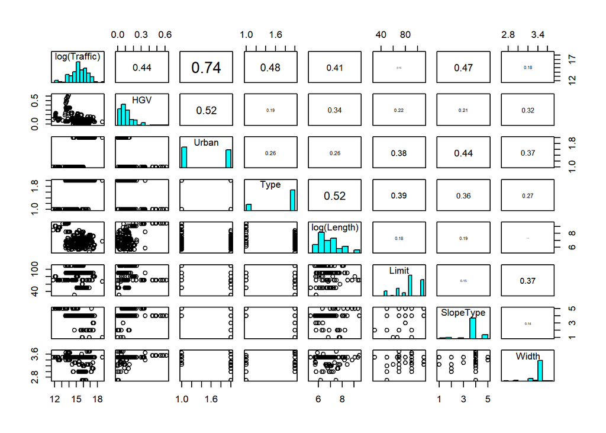

## Poisson model

```
## Generalized linear mixed model fit by maximum likelihood (Laplace
##   Approximation) [glmerMod]
##  Family: poisson  ( log )
## Formula: (Acc + 1) ~ log(Traffic) + HGV + Urban + Type + log(Length) +
##     Limit + Width + (1 | Year) + (1 | Company) + (1 | Tunnel)
##    Data: Accidents
##
##      AIC      BIC   logLik deviance df.resid
##   5450.9   5506.5  -2714.4   5428.9     1149
##
## Scaled residuals:
##     Min      1Q  Median      3Q     Max
## -4.3063 -0.7078 -0.1886  0.5017  8.4895
##
## Random effects:
##  Groups  Name        Variance Std.Dev.
##  Tunnel  (Intercept) 0.20280  0.4503
##  Company (Intercept) 0.05344  0.2312
##  Year    (Intercept) 0.01125  0.1060
## Number of obs: 1160, groups:  Tunnel, 92; Company, 25; Year, 10
##
## Fixed effects:
##                     Estimate Std. Error z value Pr(>|z|)
## (Intercept)        -4.252770   1.711285  -2.485 0.012950 *
## log(Traffic)        0.383524   0.078306   4.898 9.69e-07 ***
## HGV                 0.391435   0.731334   0.535 0.592488
## UrbanYes            0.317898   0.211037   1.506 0.131974
## TypeUnidirectional  0.637748   0.189307   3.369 0.000755 ***
## log(Length)         0.305385   0.070748   4.317 1.59e-05 ***
## Limit              -0.012057   0.003946  -3.055 0.002249 **
## Width              -0.641336   0.335268  -1.913 0.055760 .
## ---
## Signif. codes:  0 '***' 0.001 '**' 0.01 '*' 0.05 '.' 0.1 ' ' 1
##
## Correlation of Fixed Effects:
##             (Intr) lg(Tr) HGV    UrbnYs TypUnd lg(Ln) Limit
## log(Traffc) -0.685
## HGV          0.157 -0.088
## UrbanYes     0.207 -0.628  0.274
## TypUndrctnl  0.324 -0.291  0.058 -0.066
## log(Length) -0.332  0.075 -0.201 -0.023  0.302
## Limit       -0.054 -0.164 -0.064  0.333 -0.243  0.014
## Width       -0.680  0.082 -0.134  0.163 -0.361 -0.042 -0.034
## optimizer (Nelder_Mead) convergence code: 0 (OK)
## Model failed to converge with max|grad| = 0.0981073 (tol = 0.002, component 1)
## Model is nearly unidentifiable: very large eigenvalue
##  - Rescale variables?
## Model is nearly unidentifiable: large eigenvalue ratio
##  - Rescale variables?
```

```
## Generalized linear mixed model fit by maximum likelihood (Laplace
##   Approximation) [glmerMod]
##  Family: poisson  ( log )
## Formula: (Acc + 1) ~ log(Traffic) + HGV + Urban + Type + log(Length) +
##     Limit + Width + (1 | Company) + (1 | Tunnel)
##    Data: Accidents
##
##      AIC      BIC   logLik deviance df.resid
##   5490.0   5540.5  -2735.0   5470.0     1150
##
## Scaled residuals:
##     Min      1Q  Median      3Q     Max
## -4.4415 -0.6927 -0.2002  0.4755  9.3544
##
## Random effects:
##  Groups  Name        Variance Std.Dev.
##  Tunnel  (Intercept) 0.20394  0.4516
##  Company (Intercept) 0.04881  0.2209
## Number of obs: 1160, groups:  Tunnel, 92; Company, 25
##
## Fixed effects:
##                     Estimate Std. Error z value Pr(>|z|)
## (Intercept)        -4.583550   1.693679  -2.706 0.006804 **
## log(Traffic)        0.409809   0.076995   5.323 1.02e-07 ***
## HGV                 0.434500   0.731642   0.594 0.552600
## UrbanYes            0.278404   0.209216   1.331 0.183288
## TypeUnidirectional  0.631664   0.189098   3.340 0.000837 ***
## log(Length)         0.311389   0.070336   4.427 9.55e-06 ***
## Limit              -0.012512   0.003912  -3.198 0.001384 **
## Width              -0.654248   0.335007  -1.953 0.050827 .
## ---
## Signif. codes:  0 '***' 0.001 '**' 0.01 '*' 0.05 '.' 0.1 ' ' 1
##
## Correlation of Fixed Effects:
##             (Intr) lg(Tr) HGV    UrbnYs TypUnd lg(Ln) Limit
## log(Traffc) -0.679
## HGV          0.154 -0.084
## UrbanYes     0.198 -0.627  0.272
## TypUndrctnl  0.324 -0.291  0.056 -0.071
## log(Length) -0.328  0.068 -0.201 -0.018  0.304
## Limit       -0.057 -0.159 -0.065  0.337 -0.248  0.013
## Width       -0.684  0.080 -0.133  0.167 -0.360 -0.043 -0.036
## optimizer (Nelder_Mead) convergence code: 0 (OK)
## Model failed to converge with max|grad| = 0.0263697 (tol = 0.002, component 1)
## Model is nearly unidentifiable: very large eigenvalue
##  - Rescale variables?
## Model is nearly unidentifiable: large eigenvalue ratio
##  - Rescale variables?
```

## rescaling

On voit rien…

variable selection

```r
#library('MuMIn')

#model <- glmer(Acc ~ log(Traffic) + log(Length) + Limit + Type + Width + Direction + Slope + (1 | Tunnel) + (1 | Company), family=poisson, data = Accidents_new)

#mumindd <- dredge(model)
```

```
## boundary (singular) fit: see help('isSingular')
```

```
## [1] TRUE
```

```
## Generalized linear mixed model fit by maximum likelihood (Laplace
##   Approximation) [glmerMod]
##  Family: poisson  ( log )
## Formula: Acc ~ log(Traffic) + log(Length) + Limit + Type + Width + Direction +
##     Slope + (1 | Tunnel) + (1 | Company)
##    Data: Accidents_new
##
##      AIC      BIC   logLik deviance df.resid
##    446.6    464.9   -213.3    426.6       36
##
## Scaled residuals:
##     Min      1Q  Median      3Q     Max
## -4.2569 -1.2010 -0.0695  1.3646  5.0899
##
## Random effects:
##  Groups  Name        Variance Std.Dev.
##  Tunnel  (Intercept) 0.00000  0.0000
##  Company (Intercept) 0.08874  0.2979
## Number of obs: 46, groups:  Tunnel, 5; Company, 3
##
## Fixed effects:
##                      Estimate Std. Error z value Pr(>|z|)
## (Intercept)            0.6426     1.9748   0.325   0.7449
## log(Traffic)           0.3485     0.2887   1.207   0.2273
## log(Length)           -0.1301     0.4356  -0.299   0.7651
## Limit                 -0.0746     0.8781  -0.085   0.9323
## TypeUnidirectional     1.9613     2.0838   0.941   0.3466
## Width                 -0.3403     0.1650  -2.063   0.0391 *
## DirectionDirection 2   0.3657     0.1900   1.925   0.0542 .
## Slope                  0.5122     0.1044   4.904 9.37e-07 ***
## ---
## Signif. codes:  0 '***' 0.001 '**' 0.01 '*' 0.05 '.' 0.1 ' ' 1
##
## Correlation of Fixed Effects:
##             (Intr) lg(Tr) lg(Ln) Limit  TypUnd Width  DrctD2
## log(Traffc)  0.924
## log(Length) -0.042 -0.026
## Limit        0.298  0.158 -0.893
## TypUndrctnl -0.922 -0.867  0.414 -0.593
## Width        0.741  0.697 -0.652  0.726 -0.926
## DrctnDrctn2  0.028  0.024 -0.915  0.815 -0.377  0.597
## Slope        0.029  0.016 -0.612  0.559 -0.265  0.400  0.724
## optimizer (Nelder_Mead) convergence code: 0 (OK)
## boundary (singular) fit: see help('isSingular')
```

## Negative binomial ?

The residuals don’t look good at all…

```
##
## Call:
## glm.nb(formula = Acc ~ log(Traffic) + Urban + Type + log(Length) +
##     Limit + Width, data = Accidents, init.theta = 1.351412161,
##     link = log)
##
## Deviance Residuals:
##     Min       1Q   Median       3Q      Max
## -2.6854  -1.0985  -0.3425   0.3859   2.8605
##
## Coefficients:
##                     Estimate Std. Error z value Pr(>|z|)
## (Intercept)        -9.686869   1.025380  -9.447  < 2e-16 ***
## log(Traffic)        0.670814   0.050434  13.301  < 2e-16 ***
## UrbanYes            0.273889   0.116233   2.356 0.018454 *
## TypeUnidirectional  1.070273   0.121327   8.821  < 2e-16 ***
## log(Length)         0.471824   0.043875  10.754  < 2e-16 ***
## Limit              -0.018455   0.002177  -8.477  < 2e-16 ***
## Width              -0.724159   0.194262  -3.728 0.000193 ***
## ---
## Signif. codes:  0 '***' 0.001 '**' 0.01 '*' 0.05 '.' 0.1 ' ' 1
##
## (Dispersion parameter for Negative Binomial(1.3514) family taken to be 1)
##
##     Null deviance: 2540.2  on 1159  degrees of freedom
## Residual deviance: 1231.4  on 1153  degrees of freedom
## AIC: 4845.2
##
## Number of Fisher Scoring iterations: 1
##
##
##               Theta:  1.3514
##           Std. Err.:  0.0939
##
##  2 x log-likelihood:  -4829.1970
```

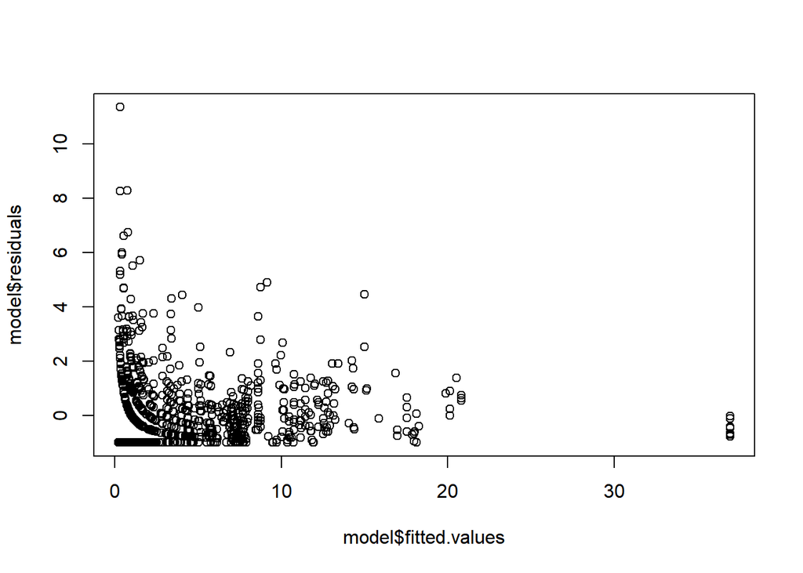

```
## Generalized linear mixed model fit by maximum likelihood (Laplace
##   Approximation) [glmerMod]
##  Family: Negative Binomial(2.7025)  ( log )
## Formula: Acc ~ log(Traffic) + Urban + Type + log(Length) + Limit + Width +
##     (1 | Year) + (1 | Company) + (1 | Tunnel)
##    Data: Accidents
##
##      AIC      BIC   logLik deviance df.resid
##   4665.7   4721.3  -2321.9   4643.7     1149
##
## Scaled residuals:
##     Min      1Q  Median      3Q     Max
## -1.4891 -0.7554 -0.1982  0.5193  6.1139
##
## Random effects:
##  Groups  Name        Variance Std.Dev.
##  Tunnel  (Intercept) 0.27243  0.5219
##  Company (Intercept) 0.09837  0.3136
##  Year    (Intercept) 0.01109  0.1053
## Number of obs: 1160, groups:  Tunnel, 92; Company, 25; Year, 10
##
## Fixed effects:
##                     Estimate Std. Error z value Pr(>|z|)
## (Intercept)        -8.825742   2.170994  -4.065 4.80e-05 ***
## log(Traffic)        0.588709   0.102918   5.720 1.06e-08 ***
## UrbanYes            0.420093   0.261946   1.604  0.10877
## TypeUnidirectional  0.977127   0.243827   4.007 6.14e-05 ***
## log(Length)         0.528427   0.092428   5.717 1.08e-08 ***
## Limit              -0.013651   0.005056  -2.700  0.00694 **
## Width              -0.885902   0.418735  -2.116  0.03437 *
## ---
## Signif. codes:  0 '***' 0.001 '**' 0.01 '*' 0.05 '.' 0.1 ' ' 1
##
## Correlation of Fixed Effects:
##             (Intr) lg(Tr) UrbnYs TypUnd lg(Ln) Limit
## log(Traffc) -0.693
## UrbanYes     0.197 -0.637
## TypUndrctnl  0.313 -0.285 -0.071
## log(Length) -0.306  0.043  0.051  0.336
## Limit       -0.033 -0.187  0.372 -0.221  0.006
## Width       -0.654  0.071  0.189 -0.368 -0.088 -0.045
## optimizer (Nelder_Mead) convergence code: 0 (OK)
## Model is nearly unidentifiable: very large eigenvalue
##  - Rescale variables?
## Model is nearly unidentifiable: large eigenvalue ratio
##  - Rescale variables?
```

[figure not shown]

## Nouveau

```
##
## Call:
## glm(formula = Acc ~ log(Traffic) + SlopeType + log(Length) +
##     Limit + Type + Width + Direction + Slope + HGV + Year, family = poisson,
##     data = Accidents)
##
## Deviance Residuals:
##     Min       1Q   Median       3Q      Max
## -5.3671  -1.3963  -0.6211   0.8021   8.9169
##
## Coefficients:
##                             Estimate Std. Error z value Pr(>|z|)
## (Intercept)               -51.286647  13.327134  -3.848 0.000119 ***
## log(Traffic)                0.626838   0.019402  32.307  < 2e-16 ***
## SlopeTypeBasin              0.886806   0.062660  14.153  < 2e-16 ***
## SlopeTypeUnknown            1.022039   0.074898  13.646  < 2e-16 ***
## SlopeTypeContinuous slope   0.144215   0.063122   2.285 0.022330 *
## SlopeTypeRoof              -0.590130   0.110795  -5.326 1.00e-07 ***
## log(Length)                 0.582956   0.023202  25.126  < 2e-16 ***
## Limit                      -0.018712   0.001069 -17.499  < 2e-16 ***
## TypeUnidirectional          0.947456   0.070321  13.473  < 2e-16 ***
## Width                      -0.614479   0.078500  -7.828 4.96e-15 ***
## DirectionDirection 2       -0.139456   0.029774  -4.684 2.82e-06 ***
## Slope                      -2.480020   0.684729  -3.622 0.000292 ***
## HGV                        -0.867039   0.265203  -3.269 0.001078 **
## Year                        0.020613   0.006641   3.104 0.001911 **
## ---
## Signif. codes:  0 '***' 0.001 '**' 0.01 '*' 0.05 '.' 0.1 ' ' 1
##
## (Dispersion parameter for poisson family taken to be 1)
##
##     Null deviance: 9676.0  on 1159  degrees of freedom
## Residual deviance: 3556.3  on 1146  degrees of freedom
## AIC: 6057.6
##
## Number of Fisher Scoring iterations: 5
```

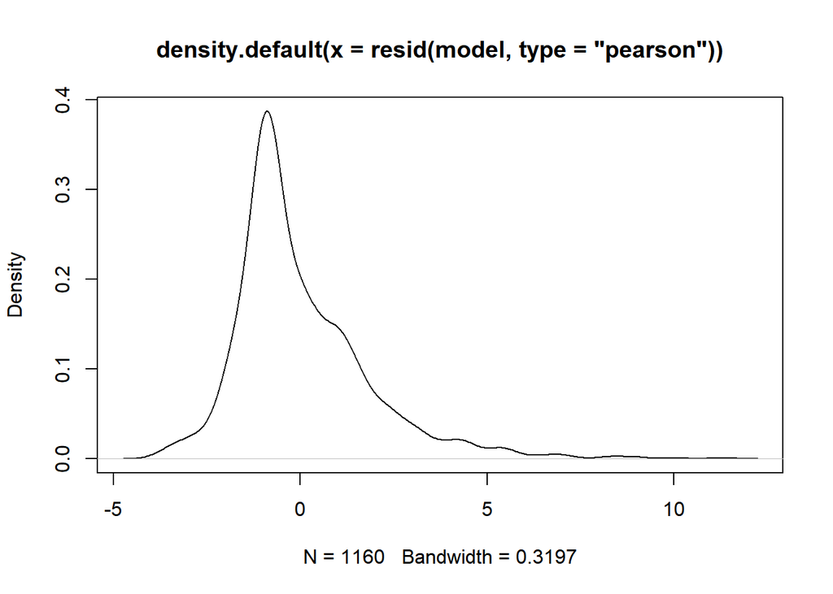

```
## [1] 1
```

```
## [1] 1146
```

```
## [1] 0
```